# Attribute data operations

```r
library(sf)
library(terra)
library(tidyverse)
library(spData)
```

# 1 Vector Attribute manipulation

Geographic vector datasets are well supported in R thanks to the `sf` class, which extends base R’s `data.frame`.

`sf` objects differ from basic data frames because they have a `geometry` column of class `sfc` which contain a range of geographic entities

**sf** also provides generics that allow `sf` objects to behavie like regular data frames, as shown by printing the class’s methods:

```r
methods(class = "sf")[1:10]
```

```
 [1] "[.sf"                      "[[<-.sf"
 [3] "[<-.sf"                    "$<-.sf"
 [5] "aggregate.sf"              "anti_join.sf"
 [7] "arrange.sf"                "as.data.frame.sf"
 [9] "cbind.sf"                  "coerce,oldClass,S3-method"
```

Let’s start by using base R functions to learn about the `world` dataset from the `spData` package:

```r
class(world)
```

```
[1] "sf"         "tbl_df"     "tbl"        "data.frame"
```

```r
dim(world)
```

```
[1] 177  11
```

Dropping geometry column before working with attribute data can be useful. Data manipulation processes can run faster when they work only on the attribute data and geometry columns are not always needed.

```r
world_df <- st_drop_geometry(world)
ncol(world_df)
```

```
[1] 10
```

## 1.1 Vector attribute subsetting

Base R subsettings methods include the operator `[` and the function `subset()`. The key `dplyr` subsetting functions are `filter()` and `slice()` for subsetting rows and `select()` for subsetting columns. Both approaches preserve the spatial components of attribute data in `sf` objetcs.

Using the operation `$` or the `dplyr` function `pull()` will lose the geometry data.

The command `object[i,j]` means return the rows represented by `i` and the columns represented by `j`, where `i` and `j` typically contain integers or `TRUE`’s and `FALSE`’s.

```r
# Subset rows by position
world[1:6, ]
```

```
Simple feature collection with 6 features and 10 fields
Geometry type: MULTIPOLYGON
Dimension:     XY
Bounding box:  xmin: -180 ymin: -18.28799 xmax: 180 ymax: 83.23324
Geodetic CRS:  WGS 84
# A tibble: 6 × 11
  iso_a2 name_long  continent region_un subregion type  area_km2     pop lifeExp
  <chr>  <chr>      <chr>     <chr>     <chr>     <chr>    <dbl>   <dbl>   <dbl>
1 FJ     Fiji       Oceania   Oceania   Melanesia Sove…   1.93e4  8.86e5    70.0
2 TZ     Tanzania   Africa    Africa    Eastern … Sove…   9.33e5  5.22e7    64.2
3 EH     Western S… Africa    Africa    Northern… Inde…   9.63e4 NA         NA
4 CA     Canada     North Am… Americas  Northern… Sove…   1.00e7  3.55e7    82.0
5 US     United St… North Am… Americas  Northern… Coun…   9.51e6  3.19e8    78.8
6 KZ     Kazakhstan Asia      Asia      Central … Sove…   2.73e6  1.73e7    71.6
# ℹ 2 more variables: gdpPercap <dbl>, geom <MULTIPOLYGON [°]>
```

```r
# Subset columns by position
world[, 1:3]
```

```
Simple feature collection with 177 features and 3 fields
Geometry type: MULTIPOLYGON
Dimension:     XY
Bounding box:  xmin: -180 ymin: -89.9 xmax: 180 ymax: 83.64513
Geodetic CRS:  WGS 84
# A tibble: 177 × 4
   iso_a2 name_long        continent                                        geom
   <chr>  <chr>            <chr>                              <MULTIPOLYGON [°]>
 1 FJ     Fiji             Oceania       (((-180 -16.55522, -179.9174 -16.50178…
 2 TZ     Tanzania         Africa        (((33.90371 -0.95, 31.86617 -1.02736, …
 3 EH     Western Sahara   Africa        (((-8.66559 27.65643, -8.817828 27.656…
 4 CA     Canada           North America (((-132.71 54.04001, -133.18 54.16998,…
 5 US     United States    North America (((-171.7317 63.78252, -171.7911 63.40…
 6 KZ     Kazakhstan       Asia          (((87.35997 49.21498, 86.82936 49.8266…
 7 UZ     Uzbekistan       Asia          (((55.96819 41.30864, 57.09639 41.3223…
 8 PG     Papua New Guinea Oceania       (((141.0002 -2.600151, 141.0171 -5.859…
 9 ID     Indonesia        Asia          (((104.37 -1.084843, 104.0108 -1.05921…
10 AR     Argentina        South America (((-68.63401 -52.63637, -68.63335 -54.…
# ℹ 167 more rows
```

```r
# Subset rows and columns by position
world[1:6, 1:3]
```

```
Simple feature collection with 6 features and 3 fields
Geometry type: MULTIPOLYGON
Dimension:     XY
Bounding box:  xmin: -180 ymin: -18.28799 xmax: 180 ymax: 83.23324
Geodetic CRS:  WGS 84
# A tibble: 6 × 4
  iso_a2 name_long      continent                                           geom
  <chr>  <chr>          <chr>                                 <MULTIPOLYGON [°]>
1 FJ     Fiji           Oceania       (((-180 -16.55522, -179.9174 -16.50178, -…
2 TZ     Tanzania       Africa        (((33.90371 -0.95, 31.86617 -1.02736, 30.…
3 EH     Western Sahara Africa        (((-8.66559 27.65643, -8.817828 27.65643,…
4 CA     Canada         North America (((-132.71 54.04001, -133.18 54.16998, -1…
5 US     United States  North America (((-171.7317 63.78252, -171.7911 63.40585…
6 KZ     Kazakhstan     Asia          (((87.35997 49.21498, 86.82936 49.82667, …
```

```r
# Columns by name
world[, c("name_long", "pop")]
```

```
Simple feature collection with 177 features and 2 fields
Geometry type: MULTIPOLYGON
Dimension:     XY
Bounding box:  xmin: -180 ymin: -89.9 xmax: 180 ymax: 83.64513
Geodetic CRS:  WGS 84
# A tibble: 177 × 3
   name_long              pop                                               geom
   <chr>                <dbl>                                 <MULTIPOLYGON [°]>
 1 Fiji                885806 (((-180 -16.55522, -179.9174 -16.50178, -179.7933…
 2 Tanzania          52234869 (((33.90371 -0.95, 31.86617 -1.02736, 30.76986 -1…
 3 Western Sahara          NA (((-8.66559 27.65643, -8.817828 27.65643, -8.7948…
 4 Canada            35535348 (((-132.71 54.04001, -133.18 54.16998, -133.2397 …
 5 United States    318622525 (((-171.7317 63.78252, -171.7911 63.40585, -171.5…
 6 Kazakhstan        17288285 (((87.35997 49.21498, 86.82936 49.82667, 85.54127…
 7 Uzbekistan        30757700 (((55.96819 41.30864, 57.09639 41.32231, 56.93222…
 8 Papua New Guinea   7755785 (((141.0002 -2.600151, 141.0171 -5.859022, 141.03…
 9 Indonesia        255131116 (((104.37 -1.084843, 104.0108 -1.059212, 103.4376…
10 Argentina         42981515 (((-68.63401 -52.63637, -68.63335 -54.8695, -67.5…
# ℹ 167 more rows
```

```r
# Logical indices
world[, c(
  TRUE,
  TRUE,
  FALSE,
  FALSE,
  FALSE,
  FALSE,
  FALSE,
  TRUE,
  TRUE,
  FALSE,
  FALSE
)]
```

```
Simple feature collection with 177 features and 4 fields
Geometry type: MULTIPOLYGON
Dimension:     XY
Bounding box:  xmin: -180 ymin: -89.9 xmax: 180 ymax: 83.64513
Geodetic CRS:  WGS 84
# A tibble: 177 × 5
   iso_a2 name_long              pop lifeExp                                geom
   <chr>  <chr>                <dbl>   <dbl>                  <MULTIPOLYGON [°]>
 1 FJ     Fiji                885806    70.0 (((-180 -16.55522, -179.9174 -16.5…
 2 TZ     Tanzania          52234869    64.2 (((33.90371 -0.95, 31.86617 -1.027…
 3 EH     Western Sahara          NA    NA   (((-8.66559 27.65643, -8.817828 27…
 4 CA     Canada            35535348    82.0 (((-132.71 54.04001, -133.18 54.16…
 5 US     United States    318622525    78.8 (((-171.7317 63.78252, -171.7911 6…
 6 KZ     Kazakhstan        17288285    71.6 (((87.35997 49.21498, 86.82936 49.…
 7 UZ     Uzbekistan        30757700    71.0 (((55.96819 41.30864, 57.09639 41.…
 8 PG     Papua New Guinea   7755785    65.2 (((141.0002 -2.600151, 141.0171 -5…
 9 ID     Indonesia        255131116    68.9 (((104.37 -1.084843, 104.0108 -1.0…
10 AR     Argentina         42981515    76.3 (((-68.63401 -52.63637, -68.63335 …
# ℹ 167 more rows
```

A demostration of the utility of using `logical` vectors for subsetting is shown in the code chunk below. This creates a new object, `small_countries`, containing nations whose surface area is smallerthat 10,000 km^2.

```r
i_small = world$area_km2 < 10000
summary(i_small)
```

```
   Mode   FALSE    TRUE
logical     170       7
```

```r
small_countries = world[i_small, ]
small_countries
```

```
Simple feature collection with 7 features and 10 fields
Geometry type: MULTIPOLYGON
Dimension:     XY
Bounding box:  xmin: -67.24243 ymin: -16.59785 xmax: 167.8449 ymax: 50.12805
Geodetic CRS:  WGS 84
# A tibble: 7 × 11
  iso_a2 name_long  continent region_un subregion type  area_km2     pop lifeExp
  <chr>  <chr>      <chr>     <chr>     <chr>     <chr>    <dbl>   <dbl>   <dbl>
1 PR     Puerto Ri… North Am… Americas  Caribbean Depe…    9225. 3534874    79.4
2 PS     Palestine  Asia      Asia      Western … Disp…    5037. 4294682    73.1
3 VU     Vanuatu    Oceania   Oceania   Melanesia Sove…    7490.  258850    71.7
4 LU     Luxembourg Europe    Europe    Western … Sove…    2417.  556319    82.2
5 <NA>   Northern … Asia      Asia      Western … Sove…    3786.      NA    NA
6 CY     Cyprus     Asia      Asia      Western … Sove…    6207. 1152309    80.2
7 TT     Trinidad … North Am… Americas  Caribbean Sove…    7738. 1354493    70.4
# ℹ 2 more variables: gdpPercap <dbl>, geom <MULTIPOLYGON [°]>
```

A more concise command, which omits the intermediary object, generates the same result:

```r
small_countries = world[world$area_km2 < 10000, ]
small_countries
```

```
Simple feature collection with 7 features and 10 fields
Geometry type: MULTIPOLYGON
Dimension:     XY
Bounding box:  xmin: -67.24243 ymin: -16.59785 xmax: 167.8449 ymax: 50.12805
Geodetic CRS:  WGS 84
# A tibble: 7 × 11
  iso_a2 name_long  continent region_un subregion type  area_km2     pop lifeExp
  <chr>  <chr>      <chr>     <chr>     <chr>     <chr>    <dbl>   <dbl>   <dbl>
1 PR     Puerto Ri… North Am… Americas  Caribbean Depe…    9225. 3534874    79.4
2 PS     Palestine  Asia      Asia      Western … Disp…    5037. 4294682    73.1
3 VU     Vanuatu    Oceania   Oceania   Melanesia Sove…    7490.  258850    71.7
4 LU     Luxembourg Europe    Europe    Western … Sove…    2417.  556319    82.2
5 <NA>   Northern … Asia      Asia      Western … Sove…    3786.      NA    NA
6 CY     Cyprus     Asia      Asia      Western … Sove…    6207. 1152309    80.2
7 TT     Trinidad … North Am… Americas  Caribbean Sove…    7738. 1354493    70.4
# ℹ 2 more variables: gdpPercap <dbl>, geom <MULTIPOLYGON [°]>
```

The base R function `subset()` provides another way to achieve the same result:

```r
small_countries = subset(world, area_km2 < 10000)
small_countries
```

```
Simple feature collection with 7 features and 10 fields
Geometry type: MULTIPOLYGON
Dimension:     XY
Bounding box:  xmin: -67.24243 ymin: -16.59785 xmax: 167.8449 ymax: 50.12805
Geodetic CRS:  WGS 84
# A tibble: 7 × 11
  iso_a2 name_long  continent region_un subregion type  area_km2     pop lifeExp
  <chr>  <chr>      <chr>     <chr>     <chr>     <chr>    <dbl>   <dbl>   <dbl>
1 PR     Puerto Ri… North Am… Americas  Caribbean Depe…    9225. 3534874    79.4
2 PS     Palestine  Asia      Asia      Western … Disp…    5037. 4294682    73.1
3 VU     Vanuatu    Oceania   Oceania   Melanesia Sove…    7490.  258850    71.7
4 LU     Luxembourg Europe    Europe    Western … Sove…    2417.  556319    82.2
5 <NA>   Northern … Asia      Asia      Western … Sove…    3786.      NA    NA
6 CY     Cyprus     Asia      Asia      Western … Sove…    6207. 1152309    80.2
7 TT     Trinidad … North Am… Americas  Caribbean Sove…    7738. 1354493    70.4
# ℹ 2 more variables: gdpPercap <dbl>, geom <MULTIPOLYGON [°]>
```

We have the following alternatives to extract variables:

```r
pull(world, pop)[1:5]
```

```
[1]    885806  52234869        NA  35535348 318622525
```

```r
world$pop[1:5]
```

```
[1]    885806  52234869        NA  35535348 318622525
```

```r
world[["pop"]][1:5]
```

```
[1]    885806  52234869        NA  35535348 318622525
```

## 1.2 Chaining commands with pipes

The native pipe operator `|>` takes its name from the Unix `|`. Pipes enable expressive code: the output of a previous function becomes the first argument of the next function, enabling chaining.

```r
world7 = world |>
  filter(continent == "Asia") |>
  select(name_long, continent) |>
  slice(1:5)
world7
```

```
Simple feature collection with 5 features and 2 fields
Geometry type: MULTIPOLYGON
Dimension:     XY
Bounding box:  xmin: 34.26543 ymin: -10.35999 xmax: 141.0339 ymax: 55.38525
Geodetic CRS:  WGS 84
# A tibble: 5 × 3
  name_long   continent                                                     geom
  <chr>       <chr>                                           <MULTIPOLYGON [°]>
1 Kazakhstan  Asia      (((87.35997 49.21498, 86.82936 49.82667, 85.54127 49.69…
2 Uzbekistan  Asia      (((55.96819 41.30864, 57.09639 41.32231, 56.93222 41.82…
3 Indonesia   Asia      (((104.37 -1.084843, 104.0108 -1.059212, 103.4376 -0.71…
4 Timor-Leste Asia      (((124.9687 -8.89279, 125.07 -9.089987, 125.0885 -9.393…
5 Israel      Asia      (((35.71992 32.70919, 35.7008 32.71601, 35.8364 32.8681…
```

Another alternative is to split the operations into multiple self-contained lines, which is recommended when developing new R packages, an approach which has the advantage of saving intermediate results with disting names which can be later inspected for debugging purposes:

```r
world9_filtered = filter(world, continent == "Asia")
world9_selected = select(world9_filtered, continent)
world9 = slice(world9_selected, 1:5)
world9
```

```
Simple feature collection with 5 features and 1 field
Geometry type: MULTIPOLYGON
Dimension:     XY
Bounding box:  xmin: 34.26543 ymin: -10.35999 xmax: 141.0339 ymax: 55.38525
Geodetic CRS:  WGS 84
# A tibble: 5 × 2
  continent                                                                 geom
  <chr>                                                       <MULTIPOLYGON [°]>
1 Asia      (((87.35997 49.21498, 86.82936 49.82667, 85.54127 49.69286, 85.1155…
2 Asia      (((55.96819 41.30864, 57.09639 41.32231, 56.93222 41.82603, 57.7865…
3 Asia      (((104.37 -1.084843, 104.0108 -1.059212, 103.4376 -0.7119459, 103.8…
4 Asia      (((124.9687 -8.89279, 125.07 -9.089987, 125.0885 -9.393173, 125.925…
5 Asia      (((35.71992 32.70919, 35.7008 32.71601, 35.8364 32.86812, 35.8211 3…
```

## 1.3 Vector attribute aggregation

Aggregation involves summarizing data with one or more grouping variables, typically from columns in the data frame to be aggregated.

We can use the `world` dataset. The aim is to find the `sum()` of country populations for each continent, resulting in a smaller data frame. This can be done with the base R function `aggregate()` as follows:

```r
world_agg1 = aggregate(
  pop ~ continent,
  FUN = sum,
  data = world,
  na.rm = TRUE
)
world_agg1
```

```
      continent        pop
1        Africa 1154946633
2          Asia 4311408059
3        Europe  669036256
4 North America  565028684
5       Oceania   37757833
6 South America  412060811
```

The result is non-spatial data frame with six rows, one per continent, and two columns reporting the name and population of each continent.

`aggregate()` is a generic function which means that it behaves differently depending on its inputs. `sf` provides the method `aggregate.sf()` which is activated automatically when `x` is an `sf` object and a `by` argument is provided:

```r
world_agg2 = aggregate(
  world["pop"],
  by = list(world$continent),
  FUN = sum,
  na.rm = TRUE
)
world_agg2
```

```
Simple feature collection with 8 features and 2 fields
Attribute-geometry relationships: aggregate (1), identity (1)
Geometry type: GEOMETRY
Dimension:     XY
Bounding box:  xmin: -180 ymin: -89.9 xmax: 180 ymax: 83.64513
Geodetic CRS:  WGS 84
                  Group.1        pop                       geometry
1                  Africa 1154946633 MULTIPOLYGON (((-11.43878 6...
2              Antarctica          0 MULTIPOLYGON (((-61.13898 -...
3                    Asia 4311408059 MULTIPOLYGON (((48.67923 14...
4                  Europe  669036256 MULTIPOLYGON (((-53.55484 2...
5           North America  565028684 MULTIPOLYGON (((-155.2222 1...
6                 Oceania   37757833 MULTIPOLYGON (((147.9141 -4...
7 Seven seas (open ocean)          0 POLYGON ((68.935 -48.625, 6...
8           South America  412060811 MULTIPOLYGON (((-68.63999 -...
```

Another alternative is:

```r
world_agg3 = world |>
  group_by(continent) |>
  summarize(pop = sum(pop, na.rm = TRUE))
world_agg3
```

```
Simple feature collection with 8 features and 2 fields
Geometry type: GEOMETRY
Dimension:     XY
Bounding box:  xmin: -180 ymin: -89.9 xmax: 180 ymax: 83.64513
Geodetic CRS:  WGS 84
# A tibble: 8 × 3
  continent                      pop                                        geom
  <chr>                        <dbl>                              <GEOMETRY [°]>
1 Africa                  1154946633 MULTIPOLYGON (((36.86623 22, 36.69069 22.2…
2 Antarctica                       0 MULTIPOLYGON (((-180 -89.9, 180 -89.9, 180…
3 Asia                    4311408059 MULTIPOLYGON (((36.14976 35.82153, 35.9050…
4 Europe                   669036256 MULTIPOLYGON (((26.29 35.29999, 25.74502 3…
5 North America            565028684 MULTIPOLYGON (((-82.26815 23.18861, -82.51…
6 Oceania                   37757833 MULTIPOLYGON (((166.7932 -15.66881, 167.00…
7 Seven seas (open ocean)          0 POLYGON ((68.935 -48.625, 68.8675 -48.83, …
8 South America            412060811 MULTIPOLYGON (((-66.95992 -54.89681, -66.4…
```

You can change many functions in the following way:

```r
world_agg5 = world |>
  st_drop_geometry() |>
  select(pop, continent, area_km2) |>
  group_by(continent) |>
  summarise(
    pop = sum(pop, na.rm = TRUE),
    area = sum(area_km2),
    n = n()
  ) |>
  ungroup() |>
  mutate(density = round(pop / area)) |>
  slice_max(pop, n = 3) |>
  arrange(desc(n))
world_agg5
```

```
# A tibble: 3 × 5
  continent        pop      area     n density
  <chr>          <dbl>     <dbl> <int>   <dbl>
1 Africa    1154946633 29946198.    51      39
2 Asia      4311408059 31252459.    47     138
3 Europe     669036256 23065219.    39      29
```

## 1.4 Vector attribute joining

Combining data from different sources is a common task in data preparation. Joins do this by combining tables base on a shared “key” variable. `dplyr` has multiple join functions including `lef_join()` and `inner_join()`.

To demonstrate joins, we will combine data on coffe production with the `world` dataset. The coffee data is in a data frame called `coffe_data` from the `spData` package. It has three columns:

- `name_long` names major coffee-producing nations
- `coffee_production_2016` contain estimated values for coffe production in units of 60-kg bags in each 2016
- `coffee_production_2017` contain estimated values for coffe production in units of 60-kg bags in each 2017

```r
coffee_data |>
  glimpse()
```

```
Rows: 47
Columns: 3
$ name_long              <chr> "Angola", "Bolivia", "Brazil", "Burundi", "Came…
$ coffee_production_2016 <int> NA, 3, 3277, 37, 8, NA, 4, 1330, 28, 114, NA, 1…
$ coffee_production_2017 <int> NA, 4, 2786, 38, 6, NA, 12, 1169, 32, 130, NA, …
```

Applying the join we have:

```r
world_coffee = world |>
  left_join(
    y = coffee_data,
    by = join_by(name_long)
  )

class(world_coffee)
```

```
[1] "sf"         "tbl_df"     "tbl"        "data.frame"
```

```r
nrow(world_coffee)
```

```
[1] 177
```

```r
names(world_coffee)
```

```
 [1] "iso_a2"                 "name_long"              "continent"
 [4] "region_un"              "subregion"              "type"
 [7] "area_km2"               "pop"                    "lifeExp"
[10] "gdpPercap"              "geom"                   "coffee_production_2016"
[13] "coffee_production_2017"
```

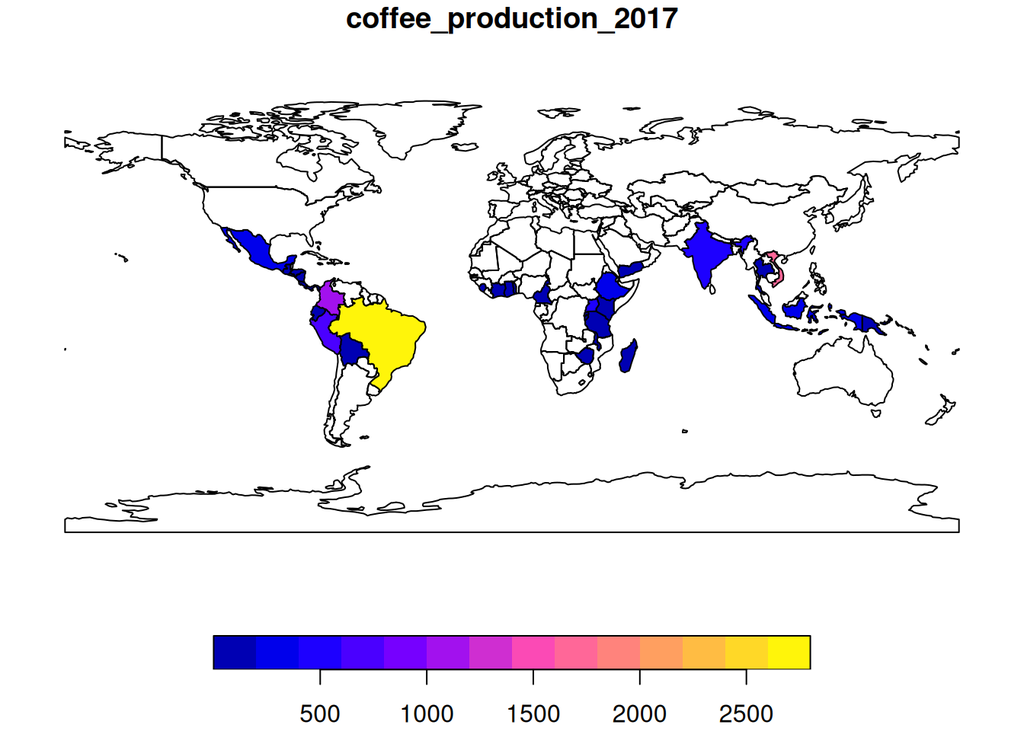

```r
plot(world_coffee[, "coffee_production_2017"])
```

For joining to work, a “key” variable must be supplied in both datasets. By default, `dplyr` uses all variables with matching names. In this cas, both `coffee_data` and `world` objects contained a variable `name_long`.

In the majority of cases where variable names are not the same, you have 2 options:

1. Rename the key variable in one of the objects so they match
2. Use the `by` argumetn to specify the joining variables

In the case of `left_join` all 177 country records are kept intact in `world_coffee`. Rows in the original dataset with no match are assigned `NA` values for the new coffee production variables. What if we only want to keep countries that have a match in the key variable? In that case, an inner join can be used:

```r
world_coffee_inner = world |>
  inner_join(
    y = coffee_data,
    by = join_by(name_long)
  )
nrow(world_coffee_inner)
```

```
[1] 45
```

## 1.5 Creating attributes and removing spatial information

```r
world_new = world |>
  mutate(pop_dens = pop / area_km2)
world_new |>
  glimpse()
```

```
Rows: 177
Columns: 12
$ iso_a2    <chr> "FJ", "TZ", "EH", "CA", "US", "KZ", "UZ", "PG", "ID", "AR", …
$ name_long <chr> "Fiji", "Tanzania", "Western Sahara", "Canada", "United Stat…
$ continent <chr> "Oceania", "Africa", "Africa", "North America", "North Ameri…
$ region_un <chr> "Oceania", "Africa", "Africa", "Americas", "Americas", "Asia…
$ subregion <chr> "Melanesia", "Eastern Africa", "Northern Africa", "Northern …
$ type      <chr> "Sovereign country", "Sovereign country", "Indeterminate", "…
$ area_km2  <dbl> 19289.97, 932745.79, 96270.60, 10036042.98, 9510743.74, 2729…
$ pop       <dbl> 885806, 52234869, NA, 35535348, 318622525, 17288285, 3075770…
$ lifeExp   <dbl> 69.96000, 64.16300, NA, 81.95305, 78.84146, 71.62000, 71.039…
$ gdpPercap <dbl> 8222.2538, 2402.0994, NA, 43079.1425, 51921.9846, 23587.3375…
$ geom      <MULTIPOLYGON [°]> MULTIPOLYGON (((-180 -16.55..., MULTIPOLYGON ((…
$ pop_dens  <dbl> 45.92054660, 56.00118428, NA, 3.54077280, 33.50132582, 6.333…
```